# Analysis_MetaMod_Markdown

Olivia Cody

4/12/2018

Todo:

- Writing: Please start writing up the results section – use the plots as well as the data frames underlying the plots.
- For each bias scenario: for each estimator: consider ME, RMSE, Type I and Type II error.
- My advice: just talk about each metric (ME, RMSE, Type I, Power) in sequence, describing whether (1) there’s a problem with the unadjusted estimator indicating that we need adjustments for pub bias, and (2) whether the adjustments make things any better, and if so, which ones work best.

## **Meta Analysis**

This simulation study tests:

1. How publication bias affects ability to detect moderators in meta-analysis
2. Whether adjustments for publication bias may improve or impair detection of moderators, given publication bias.

Data are simulated according to two scenarios:

• Medium effects: Studies have true effects of 0, 0.3, or 0.6

• Small effects: Studies have true effects of 0, 0.2, or 0.4

• Data are then subjected to publication bias and QRPs

• No bias: All study results are reported

• Biased: Only 20% of of nonsignificant results are published. 50% of studies involve aggressive p-hacking, 40% use moderate p-hacking.

• Number of studies per group is fixed to k = 20

• Studies have sample size of minimum 20/cell, maximum 200/cell, average 50/cell.

## **Analysis**

Naïve analysis: Meta-analysis tests the moderator effect without adjustment for publication bias

WLS-MRA (single slope): Meta-analysis tests the moderator effect after PET adjustment for publication bias. PET slope is fixed across groups.

WLS-MRA (variable slope): Meta-analysis tests the moderator effect after PET adjustment for publication bias. PET slope may vary across groups. Results are presented in terms of bias, root mean squared error, and Type I/II error.

## **Results**

#### **Medium effects**

**Group Means: 0, 0.3, 0.6**

Publication bias causes overestimation of δ = 0 and underestimation of mods. This underestimation causes increased Type II error rates for moderators. PET-RMA does not quite undo this bias and can have poor power and efficiency.

**Mean Estimates**

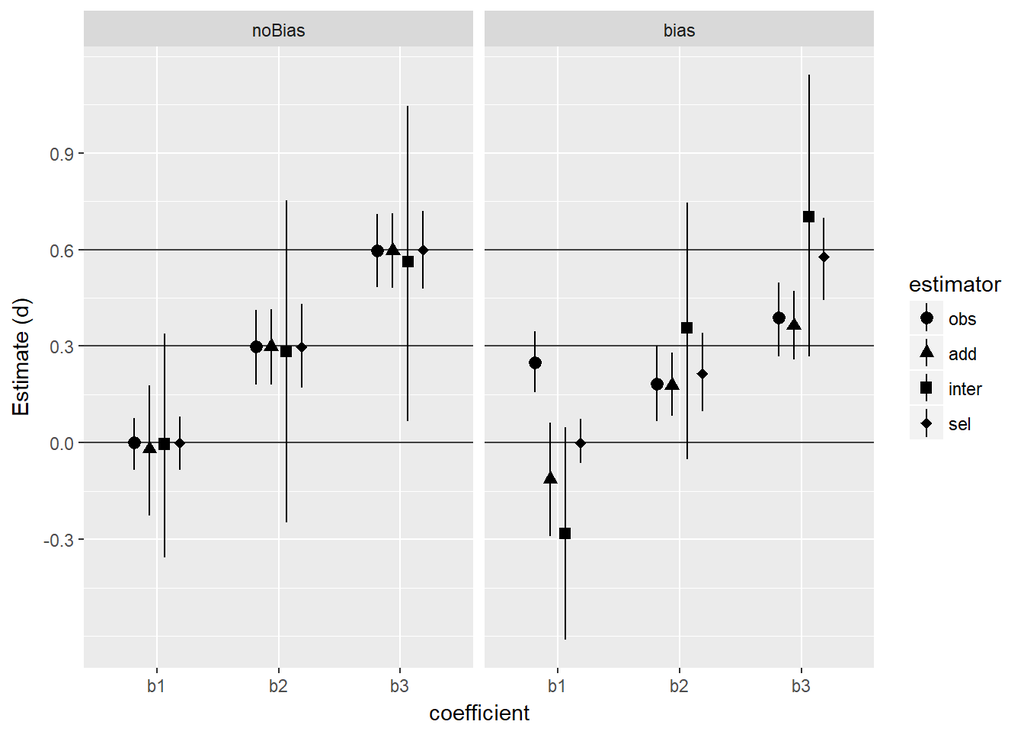

**Root Mean Squared Error**

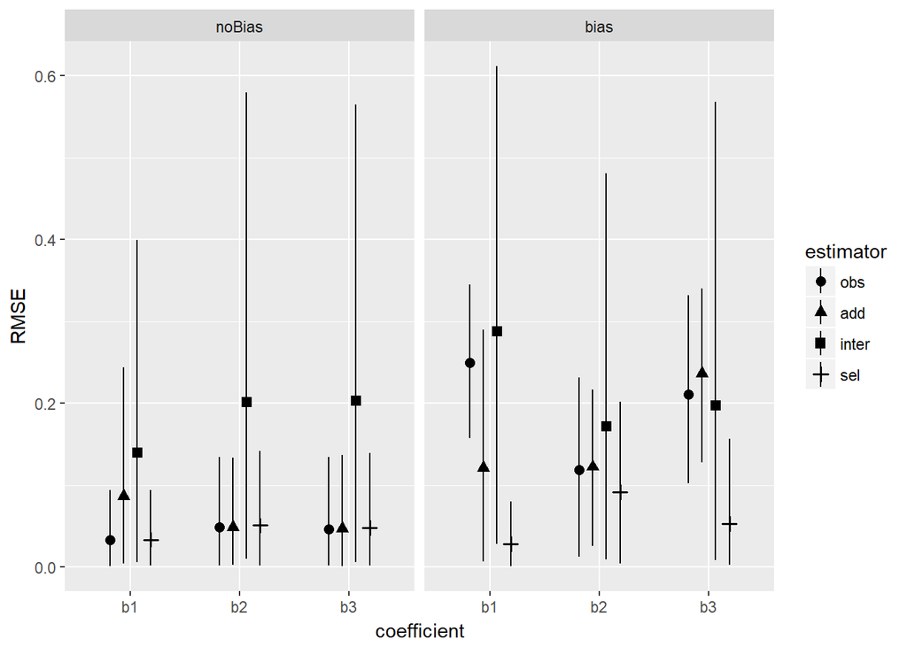

**Power/ Type I**

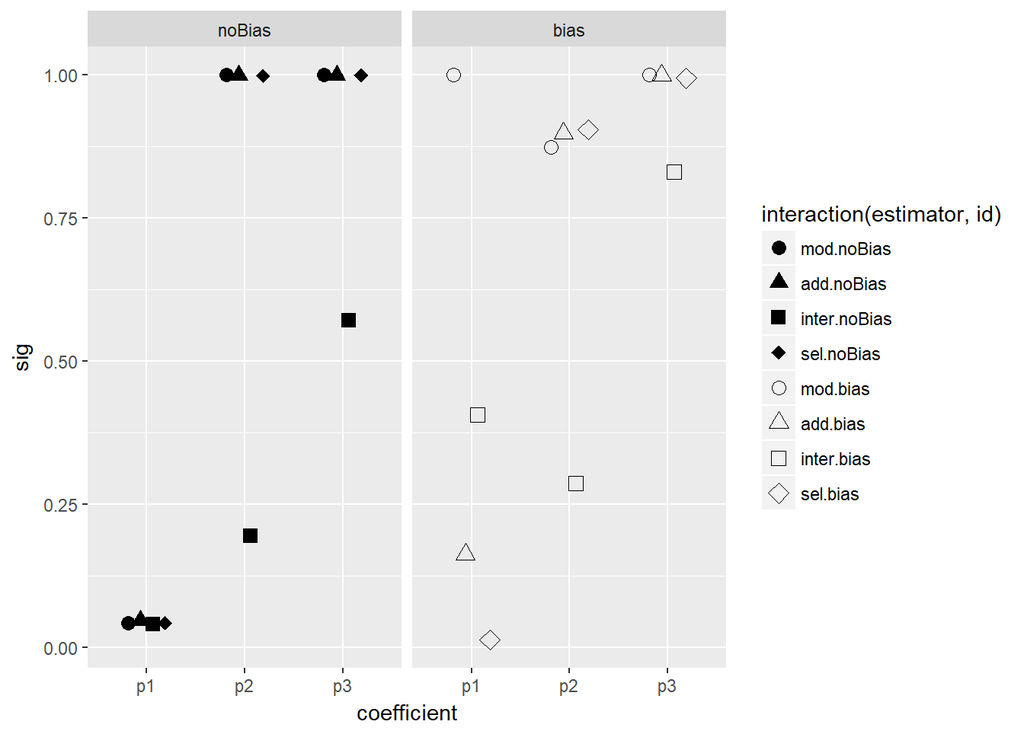

**Significance Rates**

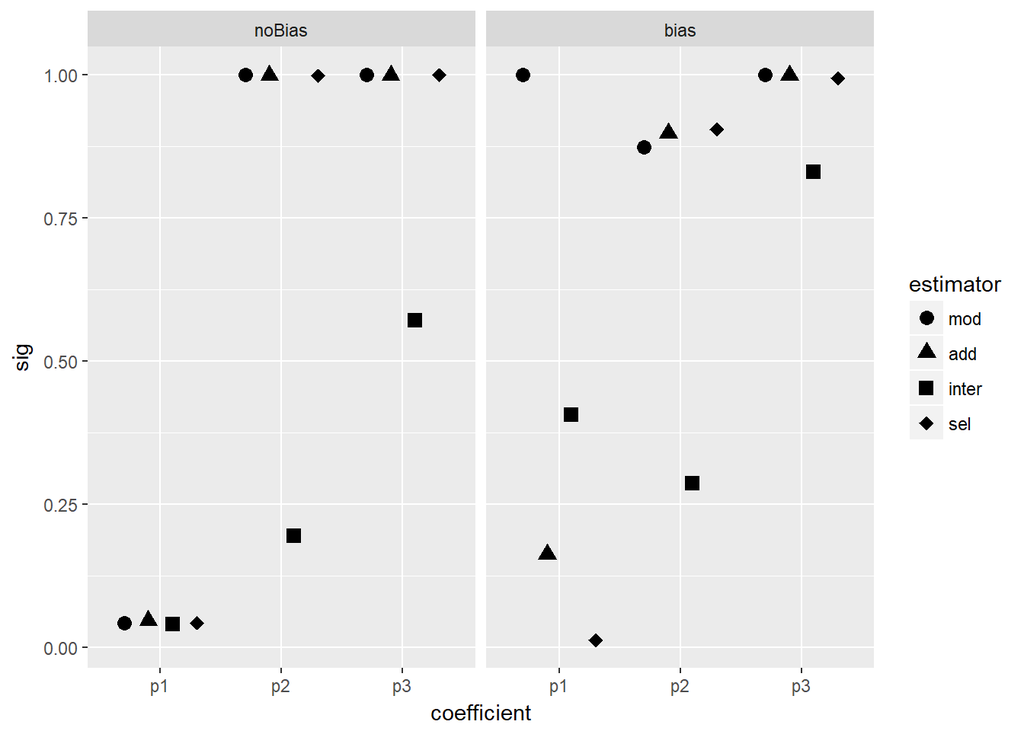

#### **Small Effects**

**Group means: 0, 0.2, 0.4**

When effects are smaller, the loss of power is more pronounced. Again, PET-RMA does not fix the biases and can inflict further loss of efficiency.

**Mean Estimates**

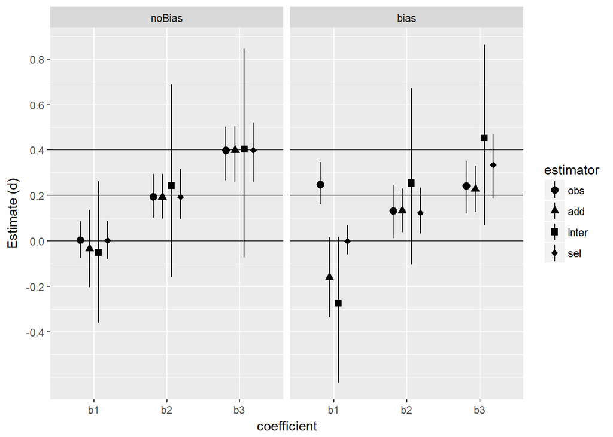

**Root Mean Squared Error**

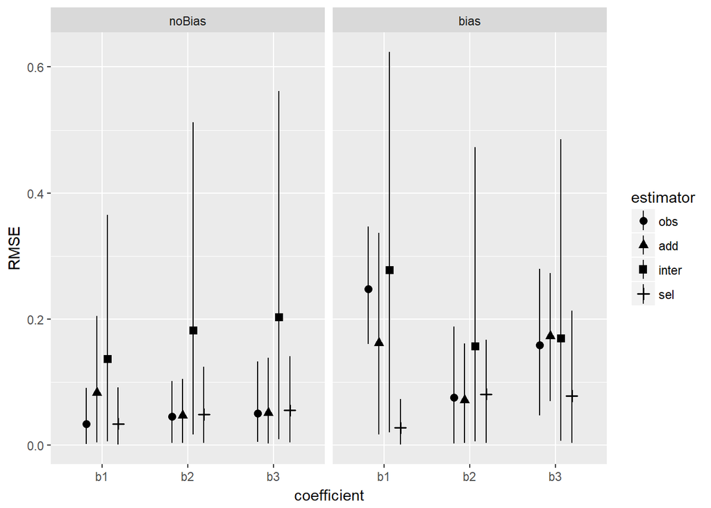

**Power/ Type I**

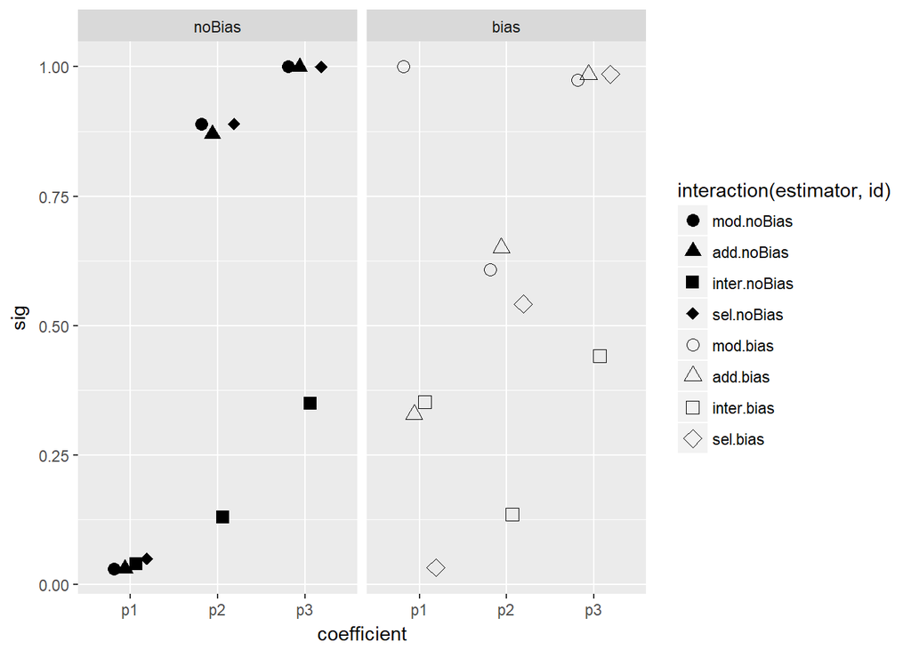

**Significance Rates**

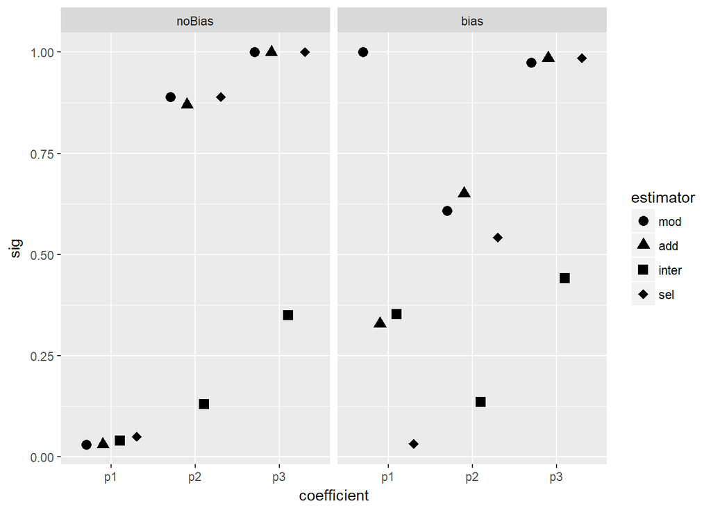

#### **No publication bias**

**Type I error rate.** Under the null, all methods had appropriate Type I error rates, with no large differences between different methods.

**Power.** For the medium effects, all models except the inter model had sufficient power. for an effect size of 0.3, the inter model only had power of around 20%. For an effect size of 0.6, the inter model had power of around 60%. Under small effects, the inter model preformed even worse, with a power of around 12% for a 0.2 effect size and around 35% for an effect size of 0.4.

**ME.** All methods were generally unbiased. For medium effects, only for a true effect size of 0.6 was there any noticeable difference, here the inter model underestimated the true effect. Under the small effects, both the add and inter models underestimated a null effect.

In terms of *SE?*, all of the methods preformed relatively equally except for the inter model. The inter model had a large standard error across all effect sizes.

**RMSE.** The obs and sel models had the lowest RMSE across all effect sizes. The add model preformed slightly worse when the null was true but not for effect sizes above 0.2. Overall, the inter model has the highest RMSE with the largest *SE* as well.

#### **Strong publication bias**

**Type I error rates.** Under the null, only the sel model performed well. All other models had a type 1 error rate higher than 0.10.

**Power.** Across all effect sizes, all models except for the inter model preformed relatively equally with acceptable power (above 80%). Only under an effect size of 0.2 did the power drop for all models. Except for the inter model, the models had power of around 60% for an effect size of 0.2. Here, the add model appeared to have the most power.

**ME.** Under the null, all methods performed poorly except the sel model which estimated the null correctly and had the smallest *SE*. The obs model overestimated the effect size to be around 0.25 and both the add and inter models underestimated the null effect. Once again the inter model had the largest *SE*.

For a medium effect of 0.3, all models under estimated the effect except for the inter model which overestimated the effect. For a medium effect of 0.6 the sel model preformed the best, only sightly underestimating the model. The obs and add model both underestimated the effect and the inter overestimated the effect.

For a small effect of 0.2, again, all models underestimated the effect except for the inter model which overestimated the effect. For a small effect of 0.4 the sel model preformed the best, only slightly underestimating the model. The obs and add model both underestimated the effect and the inter overestimated the effect.

**RMSE.** Under the null, the sel model had the lowest RSME followed by the add model and the obs and inter models preforming the worst.

In terms of *SE*, all models had relatively equal *SE* across effect sizes with the exception of the inter model which had very large *SE* across all effect sizes.

## **Conclusion**

The sel model appears to perform the best across all scenarios and the inter model preforms the worst by far.